# STOR 455 Homework #1

25 points - Due Friday 9/3 at 5:00pm

rm(list=ls())

**Directions:** This first assignment is meant to be a brief introduction to working with R in RStudio. You may (and should) collaborate with other students. If you do so, you must identify them on the work that you turn in. You should complete the assignment in an R Notebook, including all calculations, plots, and explanations. Make use of the white space outside of the R chunks for your explanations rather than using comments inside of the chunks. For your submission, you should knit the notebook to PDF and submit the file to Gradescope.

**Eastern Box Turtles:** The Box Turtle Connection is a long-term study anticipating at least 100 years of data collection on box turtles. Their purpose is to learn more about the status and trends in box turtle populations, identify threats, and develop strategies for long-term conservation of the species. Eastern Box Turtle populations are in decline in North Carolina and while they are recognized as a threatened species by the International Union for Conservation of Nature, the turtles have no protection in North Carolina. There are currently more than 30 active research study sites across the state of North Carolina. Turtles are weighed, measured, photographed, and permanently marked. These data, along with voucher photos (photos that document sightings), are then entered into centralized database managed by the NC Wildlife Resources Commission. The *Turtles* dataset (found at the link below) contains data collected at The Piedmont Wildlife Center in Durham.

https://raw.githubusercontent.com/JA-McLean/STOR455/master/data/Turtles.csv

1. The *Annuli* rings on a turtle represent growth on the scutes of the carapace and plastron. In the past, it was thought that annuli corresponded to age, but recent findings suggest that this is not the case. However, the annuli are still counted since it may yield important life history information. Construct a least squares regression line that predicts turtles’ *Annuli* by their *Mass*.

```r
turtles <- read.csv("https://raw.githubusercontent.com/JA-McLean/STOR455/master/data/Turtles.csv
") # Calling in the data
plot(Annuli~Mass, data = turtles) # Checking to see if the data looks linear, or if there are any patterns.

# The data fans out a little as mass increases, the annuli variability increases. It is not consistent.

mod1 <- lm(Annuli~Mass, turtles)
mod1
```

[output not shown]

```
Call:
lm(formula = Annuli ~ Mass, data = turtles)

Coefficients:
(Intercept)         Mass
    8.08494      0.02957
```

```r
abline(mod1)
```

2. Produce a scatterplot of this relationship (and include the least squares line on the plot).

```r
plot(Annuli~Mass, data = turtles)
abline(mod1)
```

[output not shown]

```r
plot(mod1, 1:2) # This is for me to see what other plots look like
```

[output not shown]

3. The turtle in the ninth row of the *Turtles* dataset has a mass of 325 grams. What does your model predict for this turtle’s number of *Annuli*? What is the residual for this case?

```r
# Linear Regression Line Formula: y = mx + b; y = 0.02957x + 8.08494
mass <- 325
yhat1 <- 0.02957*mass + 8.08494 #This is mod1's regression line
# Based on our model, this turtle should have 18 annuli.
# Actual:
y1 <- turtles[9, "Annuli"]
# The turtle's true # of annuli is 18.
residual1 <- yhat1-y1
residual1
```

```
[1] -0.30481
```

```r
turtles[9,]
```

|  | LifeStage | Sex | Annuli | Mass | StraightlineCL | MaxCW | PL_AnteriortoHinge | PL_HingetoPosterior | ShellHeightatHinge |
| --- | --- | --- | --- | --- | --- | --- | --- | --- | --- |
| 9 | Adult | Male | 18 | 325 | 115 | 94 | 45 | 68 | 55 |

4. Which turtle (by row number in the dataset) has the largest positive residual? What is the value of that residual?

Turtle number 185 has the largest positive residual of 23.19151.

```r
mod1 <- lm(Annuli~Mass, turtles)
turtles$residual <- mod1$residuals
max(turtles$residual)
```

```
[1] 23.19151
```

```r
x <- which.max(turtles$residual)
turtles[x,]
```

|  | LifeStage | Sex | Annuli | Mass | StraightlineCL | MaxCW | PL_AnteriortoHinge | PL_HingetoPosterior | ShellHeightatHinge | residual |
| --- | --- | --- | --- | --- | --- | --- | --- | --- | --- | --- |
| 185 | Adult | Female | 40 | 295 | 109 | 85 | 44 | 64 | 61 | 23.19151 |

5. Which turtle (by row number in the dataset) has the most negative residual? What is the value of that residual?

Turtle number 93 has the smallest residual of -10.42705.

```r
mod1 <- lm(Annuli~Mass, turtles)
turtles$residual <- mod1$residuals
min(turtles$residual)
```

```
[1] -10.42705
```

```r
y <- which.min(turtles$residual)
turtles[y,]
```

|  | LifeStage | Sex | Annuli | Mass | StraightlineCL | MaxCW | PL_AnteriortoHinge | PL_HingetoPosterior | ShellHeightatHinge | residual |
| --- | --- | --- | --- | --- | --- | --- | --- | --- | --- | --- |
| 93 | Adult | Female | 12 | 485 | 129.2 | 104.82 | 52.59 | 79.27 | 65.09 | -10.42705 |

6. Comment how the conditions for a simple linear model are met this model. Include at least two plots (in addition to the plot in question 2) - with commentary on what each plot tells you specifically about the appropriateness of conditions.

- the first scatterplot with the line shows the least squares regression model
- the fitted residuals plot shows how off our predictions were
- The normal gg plot shows what our data would look like in comparision to a normal distribution of a similar dataset.

```r
plot(Annuli~Mass, data = turtles)
abline(mod1)
```

[output not shown]

```r
plot(mod1, 1:2)
```

[output not shown]

7. Experiment with at least two transformations to determine if models constructed with these transformations appear to do a better job of satisfying the simple linear model conditions. Include the summary outputs for fitting these model and scatterplots of the transformed variable(s) with the least square lines.

```r
plot(Annuli~Mass, data = turtles) # This is the original
abline(lm(Annuli~Mass, data = turtles))
```

[output not shown]

```r
plot(lm(Annuli~Mass, data = turtles), 1:2)
```

[output not shown]

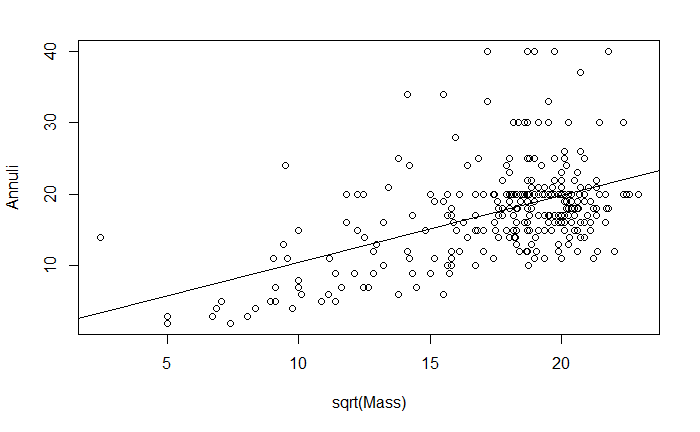

```r
# square root Mass
plot(Annuli~sqrt(Mass), data = turtles)
abline(lm(Annuli~sqrt(Mass), data = turtles))
```

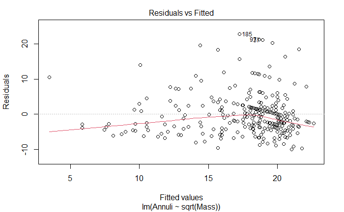

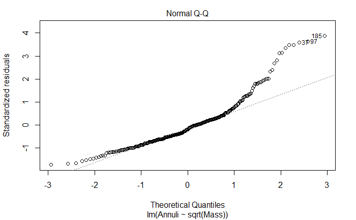

```r
plot(lm(Annuli~sqrt(Mass), data = turtles), 1:2)
```

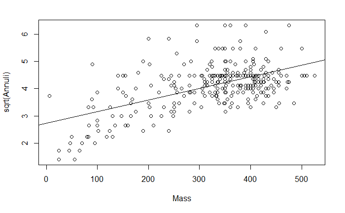

```r
# Square root Annuli
plot(sqrt(Annuli)~Mass, data = turtles)
abline(lm(sqrt(Annuli)~Mass, data = turtles))
```

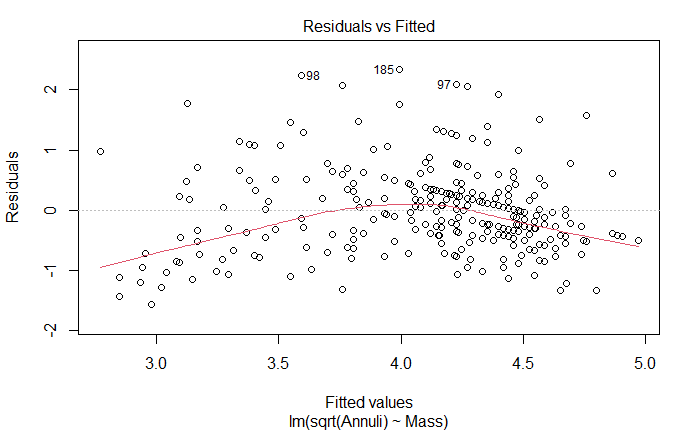

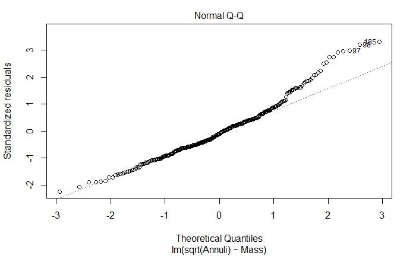

```r
plot(lm(sqrt(Annuli)~Mass, data = turtles), 1:2)
```

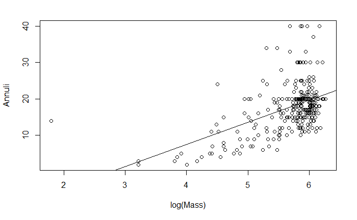

```r
# Log Mass
plot(Annuli~log(Mass), data = turtles)
abline(lm(Annuli~log(Mass), data = turtles))
```

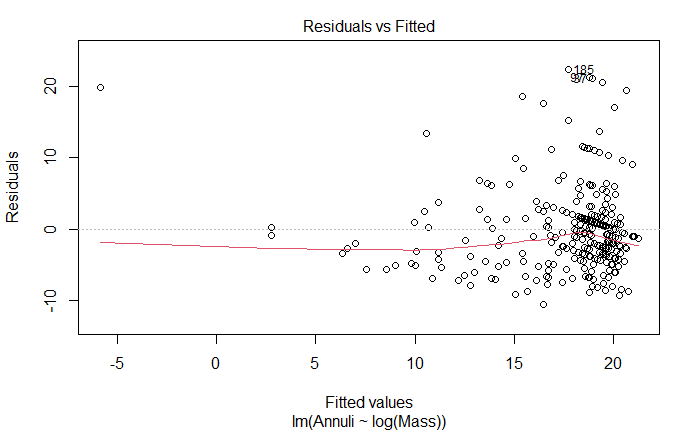

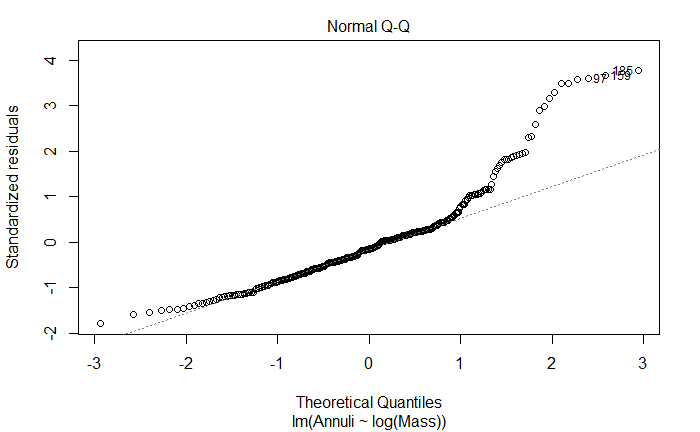

```r
plot(lm(Annuli~log(Mass), data = turtles), 1:2)
```

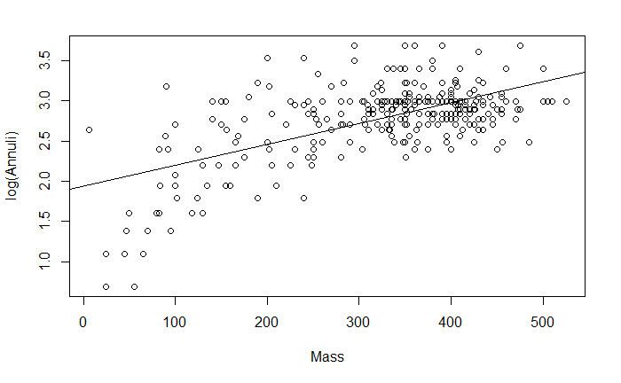

```r
# Log Annuli
plot(log(Annuli)~Mass, data = turtles)
abline(lm(log(Annuli)~Mass, data = turtles))
```

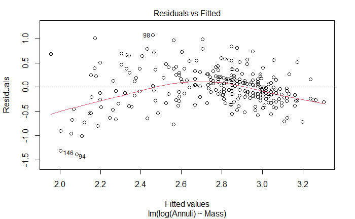

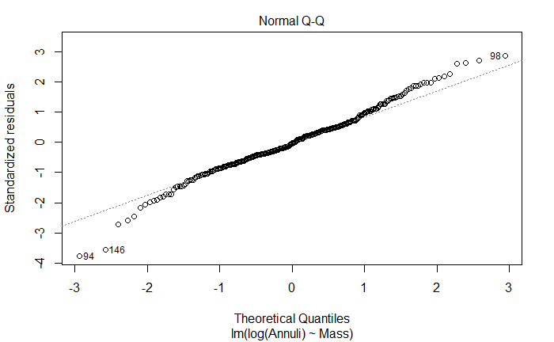

```r
plot(lm(log(Annuli)~Mass, data = turtles), 1:2)
```

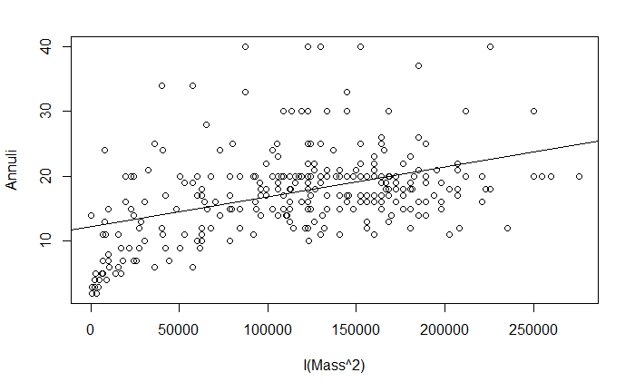

```r
# Add Exponent to Mass
plot(Annuli~I(Mass^2), data = turtles)
abline(lm(Annuli~I(Mass^2), data = turtles))
```